# Project: The Movie DataBase -tmdb

- Introduction
- Data Wrangling
- Exploratory Data Analysis
- Conclusions

## Introduction

### After Analysing the Data ,following questions could be answered:

```
1. List of movies with maximum and minimum value for each attribute - Budget,Revenue,Runtime,Popularity...
2. Year of release vs Profitability.
3. Visualtisation of Popularity vs Revenue ('high', 'mod_high', 'medium', 'low')
4. Top 10 popular Cast,Genres and Directors
5. Average runtime of the movies
```

**Importing required packages- pandas,numpy,matplotlob and seaborn**

```python
import pandas as pd
import numpy as np
import matplotlib.pyplot as plt
import seaborn as sns


%matplotlib inline
```

## Data Wrangling

### General Properties of Dataframe

```python
# Data is loaded
tmdb = pd.read_csv('tmdb-movies.csv')
tmdb.head(2)
```

|  | id | imdb_id | popularity | budget | revenue | original_title | cast | homepage | director | tagline | ... | overview | runtime | genres | production_companies | release_date | vote_count | vote_average | release_year | budget_adj | revenue_adj |
| --- | --- | --- | --- | --- | --- | --- | --- | --- | --- | --- | --- | --- | --- | --- | --- | --- | --- | --- | --- | --- | --- |
| 0 | 135397 | tt0369610 | 32.985763 | 150000000 | 1513528810 | Jurassic World | Chris Pratt\|Bryce Dallas Howard\|Irrfan Khan\|Vi... | http://www.jurassicworld.com/ | Colin Trevorrow | The park is open. | ... | Twenty-two years after the events of Jurassic ... | 124 | Action\|Adventure\|Science Fiction\|Thriller | Universal Studios\|Amblin Entertainment\|Legenda... | 6/9/15 | 5562 | 6.5 | 2015 | 1.379999e+08 | 1.392446e+09 |
| 1 | 76341 | tt1392190 | 28.419936 | 150000000 | 378436354 | Mad Max: Fury Road | Tom Hardy\|Charlize Theron\|Hugh Keays-Byrne\|Nic... | http://www.madmaxmovie.com/ | George Miller | What a Lovely Day. | ... | An apocalyptic story set in the furthest reach... | 120 | Action\|Adventure\|Science Fiction\|Thriller | Village Roadshow Pictures\|Kennedy Miller Produ... | 5/13/15 | 6185 | 7.1 | 2015 | 1.379999e+08 | 3.481613e+08 |

2 rows × 21 columns

```python
tmdb.tail(3)
```

|  | id | imdb_id | popularity | budget | revenue | original_title | cast | homepage | director | tagline | ... | overview | runtime | genres | production_companies | release_date | vote_count | vote_average | release_year | budget_adj | revenue_adj |
| --- | --- | --- | --- | --- | --- | --- | --- | --- | --- | --- | --- | --- | --- | --- | --- | --- | --- | --- | --- | --- | --- |
| 10863 | 39768 | tt0060161 | 0.065141 | 0 | 0 | Beregis Avtomobilya | Innokentiy Smoktunovskiy\|Oleg Efremov\|Georgi Z... | NaN | Eldar Ryazanov | NaN | ... | An insurance agent who moonlights as a carthie... | 94 | Mystery\|Comedy | Mosfilm | 1/1/66 | 11 | 6.5 | 1966 | 0.000000 | 0.0 |
| 10864 | 21449 | tt0061177 | 0.064317 | 0 | 0 | What's Up, Tiger Lily? | Tatsuya Mihashi\|Akiko Wakabayashi\|Mie Hama\|Joh... | NaN | Woody Allen | WOODY ALLEN STRIKES BACK! | ... | In comic Woody Allen's film debut, he took the... | 80 | Action\|Comedy | Benedict Pictures Corp. | 11/2/66 | 22 | 5.4 | 1966 | 0.000000 | 0.0 |
| 10865 | 22293 | tt0060666 | 0.035919 | 19000 | 0 | Manos: The Hands of Fate | Harold P. Warren\|Tom Neyman\|John Reynolds\|Dian... | NaN | Harold P. Warren | It's Shocking! It's Beyond Your Imagination! | ... | A family gets lost on the road and stumbles up... | 74 | Horror | Norm-Iris | 11/15/66 | 15 | 1.5 | 1966 | 127642.279154 | 0.0 |

3 rows × 21 columns

```python
tmdb.info()
```

```
<class 'pandas.core.frame.DataFrame'>
RangeIndex: 10866 entries, 0 to 10865
Data columns (total 21 columns):
id                      10866 non-null int64
imdb_id                 10856 non-null object
popularity              10866 non-null float64
budget                  10866 non-null int64
revenue                 10866 non-null int64
original_title          10866 non-null object
cast                    10790 non-null object
homepage                2936 non-null object
director                10822 non-null object
tagline                 8042 non-null object
keywords                9373 non-null object
overview                10862 non-null object
runtime                 10866 non-null int64
genres                  10843 non-null object
production_companies    9836 non-null object
release_date            10866 non-null object
vote_count              10866 non-null int64
vote_average            10866 non-null float64
release_year            10866 non-null int64
budget_adj              10866 non-null float64
revenue_adj             10866 non-null float64
dtypes: float64(4), int64(6), object(11)
memory usage: 1.7+ MB
```

### Data Cleaning

**Dropping the columns which I am not considering for Data Analysis.** **Also, removing duplicates from the Dataframe**

```python
tmdb.drop(['id','imdb_id','homepage','tagline','keywords','overview','release_date','vote_count','budget','revenue'],axis=1,inplace=True)
```

I have dropped the above listed columns and have mentioned reasons for each below:

> 1. 'id','imdb_id','homepage','tagline','keywords','overview - I will not be using these columns for analysing the questions i have mentioned above.
> 2. 'release_date'- I have planned to analyse it yearly. So Date is not required , I have kept 'release_year' column for this purpose.
> 3. 'vote_count'- I will be considerig vote_average , so dropping the 'vote_count'.
> 4. 'budget','revenue'- Since it will be better to consider 'budget_adj' and 'revenue_adj' instead of budget and revenue.

```python
tmdb.head(1)
```

|  | popularity | original_title | cast | director | runtime | genres | production_companies | vote_average | release_year | budget_adj | revenue_adj |
| --- | --- | --- | --- | --- | --- | --- | --- | --- | --- | --- | --- |
| 0 | 32.985763 | Jurassic World | Chris Pratt\|Bryce Dallas Howard\|Irrfan Khan\|Vi... | Colin Trevorrow | 124 | Action\|Adventure\|Science Fiction\|Thriller | Universal Studios\|Amblin Entertainment\|Legenda... | 6.5 | 2015 | 1.379999e+08 | 1.392446e+09 |

```python
tmdb.drop_duplicates(keep='first',inplace=True)
```

```python
tmdb.info()
```

```
<class 'pandas.core.frame.DataFrame'>
Int64Index: 10865 entries, 0 to 10865
Data columns (total 11 columns):
popularity              10865 non-null float64
original_title          10865 non-null object
cast                    10789 non-null object
director                10821 non-null object
runtime                 10865 non-null int64
genres                  10842 non-null object
production_companies    9835 non-null object
vote_average            10865 non-null float64
release_year            10865 non-null int64
budget_adj              10865 non-null float64
revenue_adj             10865 non-null float64
dtypes: float64(4), int64(2), object(5)
memory usage: 1018.6+ KB
```

```python
tmdb.describe()
```

|  | popularity | runtime | vote_average | release_year | budget_adj | revenue_adj |
| --- | --- | --- | --- | --- | --- | --- |
| count | 10865.000000 | 10865.000000 | 10865.000000 | 10865.000000 | 1.086500e+04 | 1.086500e+04 |
| mean | 0.646446 | 102.071790 | 5.975012 | 2001.321859 | 1.754989e+07 | 5.136900e+07 |
| std | 1.000231 | 31.382701 | 0.935138 | 12.813260 | 3.430753e+07 | 1.446383e+08 |
| min | 0.000065 | 0.000000 | 1.500000 | 1960.000000 | 0.000000e+00 | 0.000000e+00 |
| 25% | 0.207575 | 90.000000 | 5.400000 | 1995.000000 | 0.000000e+00 | 0.000000e+00 |
| 50% | 0.383831 | 99.000000 | 6.000000 | 2006.000000 | 0.000000e+00 | 0.000000e+00 |
| 75% | 0.713857 | 111.000000 | 6.600000 | 2011.000000 | 2.085325e+07 | 3.370173e+07 |
| max | 32.985763 | 900.000000 | 9.200000 | 2015.000000 | 4.250000e+08 | 2.827124e+09 |

**budget_adj,revenue_adj and Runtime should not have zero values...Hence dropping the NA values first and then will check for zero values**

```python
tmdb.dropna(inplace=True)
```

```python
tmdb.info()
```

```
<class 'pandas.core.frame.DataFrame'>
Int64Index: 9772 entries, 0 to 10865
Data columns (total 11 columns):
popularity              9772 non-null float64
original_title          9772 non-null object
cast                    9772 non-null object
director                9772 non-null object
runtime                 9772 non-null int64
genres                  9772 non-null object
production_companies    9772 non-null object
vote_average            9772 non-null float64
release_year            9772 non-null int64
budget_adj              9772 non-null float64
revenue_adj             9772 non-null float64
dtypes: float64(4), int64(2), object(5)
memory usage: 916.1+ KB
```

**'budget_adj' ,'revenue_adj' , 'runtime' of a movie cannot not be zero so in order to fix that issue, we will replace 0 with NaN and then drop those values.**

**[How to handle null values?](https://stackoverflow.com/questions/22649693/drop-rows-with-all-zeros-in-pandas-data-frame)** **Used this link to understand how to replace 0 with NaN**

**Dropping zero values -as they might effect the analysis**

```python
tmdb['budget_adj'] = tmdb['budget_adj'].replace(0,np.NaN)
tmdb['revenue_adj'] = tmdb['revenue_adj'].replace(0,np.NaN)
tmdb['runtime'] = tmdb['runtime'].replace(0,np.NaN)
```

```python
tmdb.dropna(inplace=True) # dropped all the columns with zero values, this might be a limitation of this project as it has dropped many rows
```

```python
tmdb.info()
```

```
<class 'pandas.core.frame.DataFrame'>
Int64Index: 3805 entries, 0 to 10848
Data columns (total 11 columns):
popularity              3805 non-null float64
original_title          3805 non-null object
cast                    3805 non-null object
director                3805 non-null object
runtime                 3805 non-null float64
genres                  3805 non-null object
production_companies    3805 non-null object
vote_average            3805 non-null float64
release_year            3805 non-null int64
budget_adj              3805 non-null float64
revenue_adj             3805 non-null float64
dtypes: float64(5), int64(1), object(5)
memory usage: 356.7+ KB
```

**Change the column DataTypes :**

```python
change_coltype = ['budget_adj', 'revenue_adj','runtime','vote_average']
```

```python
tmdb[change_coltype] = tmdb[change_coltype].applymap(np.int64)
```

```python
##recheking column types
tmdb.info()
```

```
<class 'pandas.core.frame.DataFrame'>
Int64Index: 3805 entries, 0 to 10848
Data columns (total 11 columns):
popularity              3805 non-null float64
original_title          3805 non-null object
cast                    3805 non-null object
director                3805 non-null object
runtime                 3805 non-null int64
genres                  3805 non-null object
production_companies    3805 non-null object
vote_average            3805 non-null int64
release_year            3805 non-null int64
budget_adj              3805 non-null int64
revenue_adj             3805 non-null int64
dtypes: float64(1), int64(5), object(5)
memory usage: 356.7+ KB
```

**Insert a new column -Profit, which calculated profit of movie(revenue-budget)**

```python
tmdb['profit'] = tmdb['revenue_adj'] - tmdb['budget_adj']
```

```python
tmdb.info()
```

```
<class 'pandas.core.frame.DataFrame'>
Int64Index: 3805 entries, 0 to 10848
Data columns (total 12 columns):
popularity              3805 non-null float64
original_title          3805 non-null object
cast                    3805 non-null object
director                3805 non-null object
runtime                 3805 non-null int64
genres                  3805 non-null object
production_companies    3805 non-null object
vote_average            3805 non-null int64
release_year            3805 non-null int64
budget_adj              3805 non-null int64
revenue_adj             3805 non-null int64
profit                  3805 non-null int64
dtypes: float64(1), int64(6), object(5)
memory usage: 386.4+ KB
```

## Exploratory Data Analysis

### Question 1 : List of movies with maximum and minimum value for each attribute - Budget,Revenue,Runtime,Popularity

#### Build a function to find max and minimum values for all the columns : This function will return the entire row with the max and min vallues of the column passed in the function.

```python
def max_min(column_name):


    max_value = tmdb[column_name].idxmax()

    max_details = pd.DataFrame(tmdb.loc[max_value])


    min_value = tmdb[column_name].idxmin()
    min_details = pd.DataFrame(tmdb.loc[min_value])

    both_values = pd.concat([max_details, min_details], axis = 1)

    return (both_values)
```

**i) Details of movie with maximum and minimum Popularity**

```python
max_min('popularity')
```

|  | 0 | 6065 |
| --- | --- | --- |
| popularity | 32.9858 | 0.010335 |
| original_title | Jurassic World | Ð¡Ñ‚Ð°Ð»Ð¸Ð½Ð³Ñ€Ð°Ð´ |
| cast | Chris Pratt\|Bryce Dallas Howard\|Irrfan Khan\|Vi... | Thomas Kretschmann\|Yanina Studilina\|Philippe R... |
| director | Colin Trevorrow | Fyodor Bondarchuk |
| runtime | 124 | 131 |
| genres | Action\|Adventure\|Science Fiction\|Thriller | War\|Action |
| production_companies | Universal Studios\|Amblin Entertainment\|Legenda... | Art Pictures Studio |
| vote_average | 6 | 5 |
| release_year | 2015 | 2013 |
| budget_adj | 137999939 | 28081000 |
| revenue_adj | 1392445892 | 63771501 |
| profit | 1254445953 | 35690501 |

**ii) Details of movie with maximum and minimum Budget**

```python
max_min('budget_adj')
```

|  | 2244 | 3581 |
| --- | --- | --- |
| popularity | 0.25054 | 0.52043 |
| original_title | The Warrior's Way | Love, Wedding, Marriage |
| cast | Kate Bosworth\|Jang Dong-gun\|Geoffrey Rush\|Dann... | Mandy Moore\|Kellan Lutz\|Jessica Szohr\|Autumn F... |
| director | Sngmoo Lee | Dermot Mulroney |
| runtime | 100 | 90 |
| genres | Adventure\|Fantasy\|Action\|Western\|Thriller | Comedy\|Romance |
| production_companies | Boram Entertainment Inc. | 120dB Films\|Scion Films\|Voodoo Production Serv... |
| vote_average | 6 | 5 |
| release_year | 2010 | 2011 |
| budget_adj | 425000000 | 0 |
| revenue_adj | 11087569 | 1335 |
| profit | -413912431 | 1335 |

**iii) Details of movie with maximum and minimum Revenue**

```python
max_min('revenue_adj')
```

|  | 1386 | 5067 |
| --- | --- | --- |
| popularity | 9.43277 | 0.462609 |
| original_title | Avatar | Shattered Glass |
| cast | Sam Worthington\|Zoe Saldana\|Sigourney Weaver\|S... | Hayden Christensen\|Peter Sarsgaard\|ChloÃ« Sevi... |
| director | James Cameron | Billy Ray |
| runtime | 162 | 94 |
| genres | Action\|Adventure\|Fantasy\|Science Fiction | Drama\|History |
| production_companies | Ingenious Film Partners\|Twentieth Century Fox ... | Lions Gate Films\|Cruise/Wagner Productions\|Bau... |
| vote_average | 7 | 6 |
| release_year | 2009 | 2003 |
| budget_adj | 240886902 | 7112115 |
| revenue_adj | 2827123750 | 2 |
| profit | 2586236848 | -7112113 |

**iv) Details of movie with maximum and minimum Runtime**

```python
max_min('runtime')
```

|  | 2107 | 5162 |
| --- | --- | --- |
| popularity | 0.534192 | 0.208637 |
| original_title | Carlos | Kid's Story |
| cast | Edgar Ramírez\|Alexander Scheer\|Fadi Abi Samra... | Clayton Watson\|Keanu Reeves\|Carrie-Anne Moss\|K... |
| director | Olivier Assayas | Shinichiro Watanabe |
| runtime | 338 | 15 |
| genres | Crime\|Drama\|Thriller\|History | Science Fiction\|Animation |
| production_companies | Egoli Tossell Film AG\|Canal+\|Arte France\|Films... | Studio 4°C |
| vote_average | 6 | 6 |
| release_year | 2010 | 2003 |
| budget_adj | 18000000 | 11 |
| revenue_adj | 871279 | 5 |
| profit | -17128721 | -6 |

Maximum Runtime movie : Carlos  
Minimum Runtime Movie : Kid's Story

**v) Most latest and oldest movie in this Dataframe**

```python
max_min('release_year')
```

|  | 0 | 10141 |
| --- | --- | --- |
| popularity | 32.9858 | 2.61036 |
| original_title | Jurassic World | Psycho |
| cast | Chris Pratt\|Bryce Dallas Howard\|Irrfan Khan\|Vi... | Anthony Perkins\|Vera Miles\|John Gavin\|Janet Le... |
| director | Colin Trevorrow | Alfred Hitchcock |
| runtime | 124 | 109 |
| genres | Action\|Adventure\|Science Fiction\|Thriller | Drama\|Horror\|Thriller |
| production_companies | Universal Studios\|Amblin Entertainment\|Legenda... | Shamley Productions |
| vote_average | 6 | 8 |
| release_year | 2015 | 1960 |
| budget_adj | 137999939 | 5949601 |
| revenue_adj | 1392445892 | 235934958 |
| profit | 1254445953 | 229985357 |

Latest movie : Jurassic World  
Oldest Movie : Psycho

**vi) Minimum and Maximum vote_average**

```python
max_min('vote_average')
```

|  | 9 | 4859 |
| --- | --- | --- |
| popularity | 6.3268 | 0.111351 |
| original_title | Inside Out | Foodfight! |
| cast | Amy Poehler\|Phyllis Smith\|Richard Kind\|Bill Ha... | Charlie Sheen\|Wayne Brady\|Hilary Duff\|Eva Long... |
| director | Pete Docter | Lawrence Kasanoff |
| runtime | 94 | 87 |
| genres | Comedy\|Animation\|Family | Animation\|Action\|Comedy\|Family |
| production_companies | Walt Disney Pictures\|Pixar Animation Studios\|W... | Threshold Entertainment\|Lions Gate Family Ente... |
| vote_average | 8 | 2 |
| release_year | 2015 | 2012 |
| budget_adj | 160999929 | 61733378 |
| revenue_adj | 785411574 | 70001 |
| profit | 624411645 | -61663377 |

*Inside out got the maximum vote_average and Foodfight!! got the minimum*

### Question 2 : Year of Release vs Profitability.

```python
pop_year = tmdb.groupby('release_year')['popularity'].sum()
```

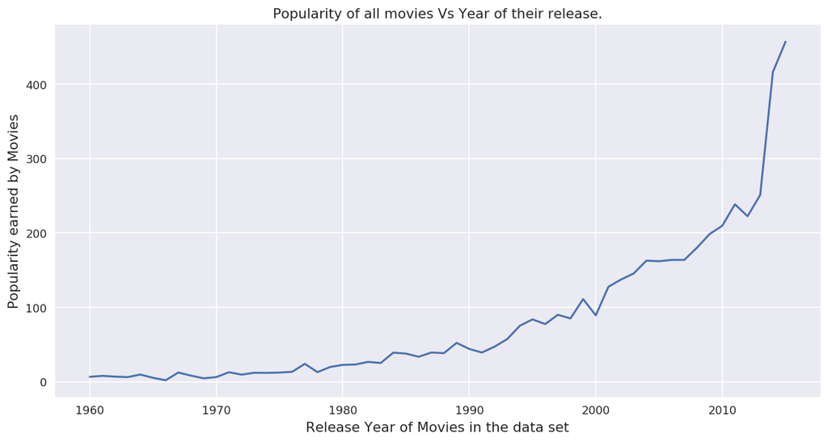

```python
plt.figure(figsize=(12,6), dpi = 130)
plt.xlabel('Release Year of Movies in the data set', fontsize = 12)
plt.ylabel('Popularity earned by Movies', fontsize = 12)
plt.title('Popularity of all movies Vs Year of their release.')
plt.plot(pop_year)
```

**The above graph shows that popularity of movies is increased with years.**

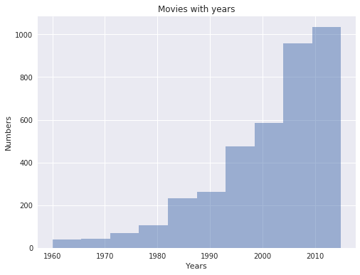

```python
fig, ax = plt.subplots(figsize=(8,6))
#ax.hist(tmdb['runtime'],alpha=0.5,label='runtime')
ax.hist(tmdb['release_year'],alpha=0.5,label='release_year')
ax.set_xlabel('Years')
ax.set_ylabel('Numbers')
ax.set_title('Movies with years')


plt.show()
```

**This graph shows that number of movies in Dataframe also increased with years..**

### Question 3 : Visualtisation of Popularity vs Revenue ('high', 'mod_high', 'medium', 'low')

```python
rev_data = tmdb.describe().revenue_adj
```

```python
bin_edges =[rev_data[3],rev_data[4],rev_data[5],rev_data[6],rev_data[7]]
bin_edges
```

```
[2.0, 19253711.0, 62846878.0, 165805400.0, 2827123750.0]
```

```python
bin_names = ['high', 'mod_high', 'medium', 'low']
```

```python
tmdb['new_pop'] = pd.cut(tmdb['revenue_adj'], bin_edges, labels=bin_names)
```

```
Text(0.5,1,'Pop vs Revenue')
```

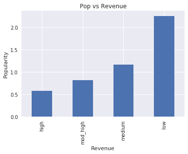

```python
pop_plot= tmdb.groupby('new_pop')['popularity'].mean()

fig = pop_plot.plot.bar()
fig.set_xlabel('Revenue')
fig.set_ylabel('Popularity')
fig.set_title('Pop vs Revenue')
```

### Question 4 : Popular Cast and Genres and Director

```
Tom Hanks             34
Harrison Ford         34
Sylvester Stallone    34
Morgan Freeman        34
Johnny Depp           35
Matt Damon            36
Nicolas Cage          43
Samuel L. Jackson     44
Bruce Willis          46
Robert De Niro        52
dtype: int64
```

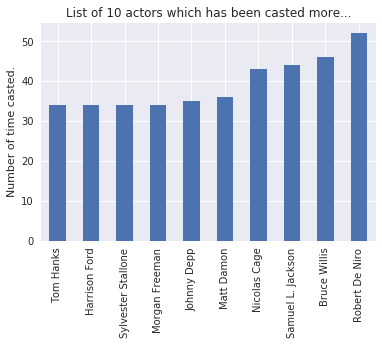

```python
actor = tmdb["cast"].str.cat(sep="|").split("|")

table=pd.Series(actor).value_counts(ascending=True)[-10:]
graph = table.plot.bar()
graph.set(title = "List of 10 actors which has been casted more...",ylabel = "Number of time casted.")

print(table)
```

```
Family              417
Horror              459
Science Fiction     517
Crime               649
Romance             658
Adventure           743
Action             1076
Thriller           1194
Comedy             1335
Drama              1729
dtype: int64
```

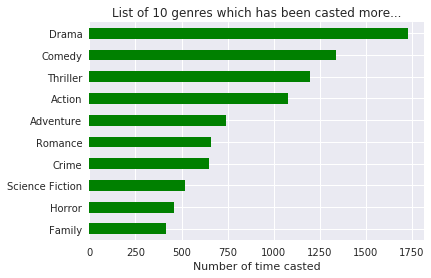

```python
actor = tmdb['genres'].str.cat(sep="|").split("|")

table_gen =pd.Series(actor).value_counts(ascending=True)[10:]
graph = table_gen.plot.barh(color='green')
graph.set(title = "List of 10 genres which has been casted more...",xlabel = "Number of time casted")

print(table_gen)
```

```python
director = pd.Series(tmdb['director']).value_counts()[:10]
```

```
Steven Spielberg     27
Clint Eastwood       24
Ridley Scott         21
Woody Allen          18
Martin Scorsese      17
Steven Soderbergh    17
Tim Burton           16
Brian De Palma       15
Robert Zemeckis      15
Oliver Stone         15
Name: director, dtype: int64
```

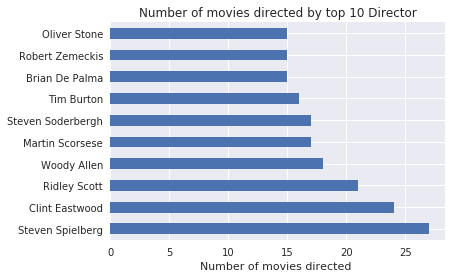

```python
plot_director = director.plot.barh()
plot_director.set(title = "Number of movies directed by top 10 Director",xlabel = "Number of movies directed ")

print(director)
```

### Question 5 : Average runtime of the movies

```python
runtim_avg = tmdb['runtime'].mean()
print('Average runtime of movie is %f'%runtim_avg)
```

```
Average runtime of movie is 109.351117
```

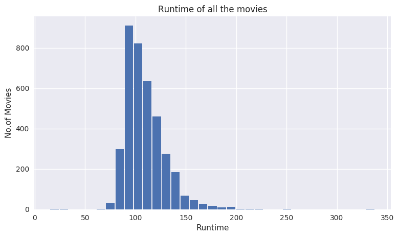

```python
plt.figure(figsize=(9,5), dpi = 100)

plt.xlabel('Runtime')
plt.ylabel('No.of Movies')
plt.title('Runtime of all the movies')

plt.hist(tmdb['runtime'], rwidth = 0.9, bins =35)
#displays the plot
plt.show()
```

The above graph also confirms the average runtime. Lets make another box plot for the same using seaborn

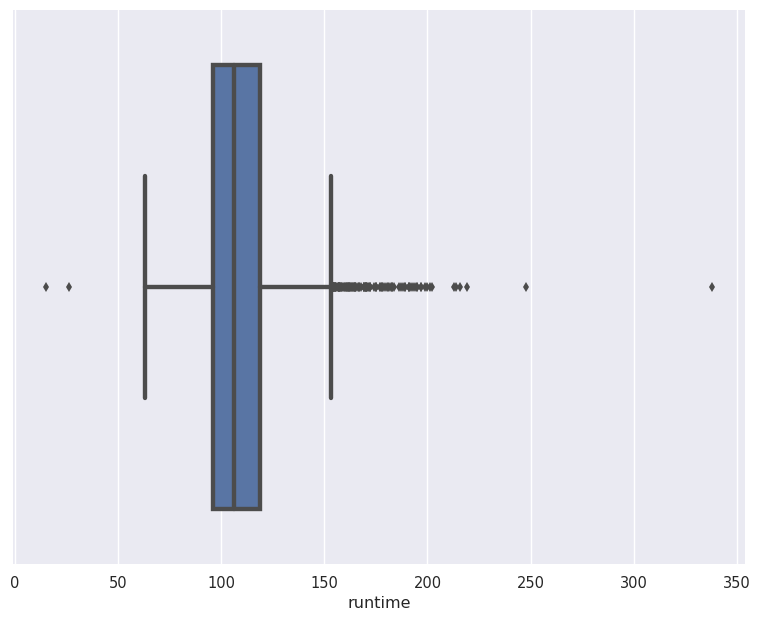

```python
plt.figure(figsize=(9,7), dpi = 105)

sns.boxplot(tmdb['runtime'], linewidth = 3)
sns.set(color_codes=True)


plt.show()
```

This also proofs the average runtime is approx 109

```python
avg_revenue = tmdb['revenue_adj'].mean()
avg_revenue
```

```
138715933.86754271
```

```python
avg_budget = tmdb['budget_adj'].mean()
avg_budget
```

```
44719764.81340342
```

## Comparing two variables :

**Scatter plot between Revenue and Popularity**

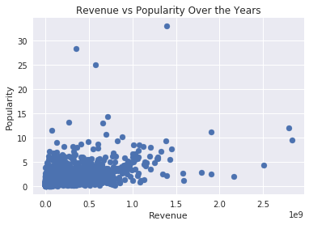

```python
plt.scatter(x=tmdb['revenue_adj'], y=tmdb['popularity'])
plt.xlabel('Revenue')
plt.ylabel('Popularity')
plt.title('Revenue vs Popularity Over the Years');
```

**plot between Release Year and Profit**

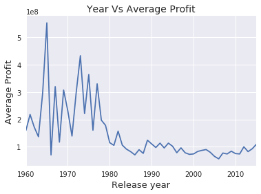

```python
tmdb.groupby('release_year')['profit'].mean().plot()

#setup the title and labels of the figure.
plt.title("Year Vs Average Profit",fontsize = 14)
plt.xlabel('Release year',fontsize = 13)
plt.ylabel('Average Profit',fontsize = 13)

#setup the figure size.
sns.set(rc={'figure.figsize':(10,5)})
sns.set_style("whitegrid")
sns.set(color_codes=True)
```

**According to the plot year 1960-1970 the most profitable years And the profit was very low between the years 2000-2010**

**Plot between Runtime and Profit**

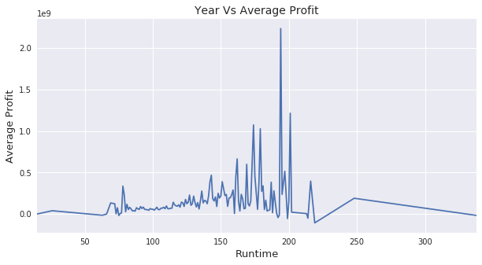

```python
tmdb.groupby('runtime')['profit'].mean().plot()

#setup the title and labels of the figure.
plt.title("Year Vs Average Profit",fontsize = 14)
plt.xlabel('Runtime',fontsize = 13)
plt.ylabel('Average Profit',fontsize = 13)

#setup the figure size.
sns.set(rc={'figure.figsize':(10,5)})
sns.set_style("whitegrid")
sns.set(color_codes=True)
```

**According to the plot runtime between 150-200 had the most profit.**

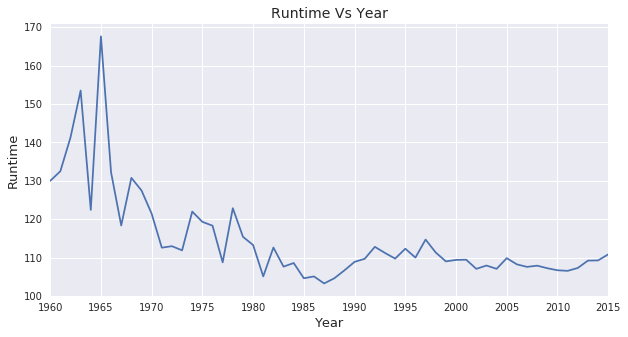

```python
tmdb.groupby('release_year').mean()['runtime'].plot(xticks = np.arange(1960,2016,5))

#setup the figure size.
sns.set(rc={'figure.figsize':(10,5)})

#setup the title of the figure
plt.title("Runtime Vs Year",fontsize = 14)

#setup the x-label and y-label of the plot.
plt.xlabel('Year',fontsize = 13)
plt.ylabel('Runtime',fontsize = 13)
sns.set_style("whitegrid")
sns.set(color_codes=True)
```

The above graph shows the earlier runtime of movies was more and has been decreased recently.

## Conclusions

### Limitations

i) The Data had lot of zero values and Null values and we have deleted that columns which might have resulted in loosing valuable data.  
ii) Also,budget and revenue column do not have currency unit, it might be possible different movies have budget in different currency.

```python
from subprocess import call
call(['python', '-m', 'nbconvert', 'Investigate_a_Dataset.ipynb'])
```

```
0
```